# Group 5 期中專案競賽

第五組 詹孟凌 陳聖勳 歐陽昱弘 王逸琦 陳昭穎 邱聖凱

2019-11-03 21:20:58

### § 前置作業

```r
pacman::p_load(dplyr, ggplot2, readr, ggmap, maps, tm, SnowballC, wordcloud2, RColorBrewer, stringr,slam,EnvStats, gganimate, gifski)
```

```r
 #ADD G DATA
 # G = read_csv("data/olist_geolocation_dataset.csv")
 # R = read_csv("data/olist_order_reviews_dataset.csv")
 # L = read_csv("data/olist_marketing_qualified_leads_dataset.csv")
 # Q = read_csv("data/olist_closed_deals_dataset.csv")
 # I = read_csv("data/olist_order_items_dataset.csv")
 # C = read_csv("data/olist_customers_dataset.csv")
 # O = read_csv("data/olist_orders_dataset.csv")
 # P = read_csv("data/olist_products_dataset.csv")
 # S = read_csv("data/olist_sellers_dataset.csv")
 # TPC = read_csv("data/product_category_name_translation.csv")
 # load("data/R.rdata")
 #
 # attr(G, "spec") = NULL
 # attr(R, "spec") = NULL
 # attr(L, "spec") = NULL
 # attr(Q, "spec") = NULL
 # attr(I, "spec") = NULL
 # attr(C, "spec") = NULL
 # attr(O, "spec") = NULL
 # attr(P, "spec") = NULL
 # attr(S, "spec") = NULL
 # attr(TPC, "spec") = NULL
 #
 # save(G,R,L,Q,I,C,O,P,S,TPC, file="data/olistdata.rdata")
```

💡 讀完原始資料之後，先將資料壓縮起來，之後再從壓縮檔讀進會比較快、比較方便

```r
rm(list=ls(all=T))
load("data/olistdata.rdata")
```

### ◆ Part.1 資料探索

##### 顧客分析

- 一次性顧客佔了96.9%，過多

```r
Q <- group_by(C, customer_unique_id) %>% summarise(nid=n())
dim(Q)
```

```
[1] 96096     2
```

```r
table(Q$nid) %>% prop.table() %>% round(3)
```

```
    1     2     3     4     5     6     7     9    17
0.969 0.029 0.002 0.000 0.000 0.000 0.000 0.000 0.000
```

##### 評論分析

- 一星至五星

```r
#下圖由左至右分別表示1~5星的評價比數各有多少。
OR <- left_join(O,R,by="order_id")
OR$review_score %>% table %>% prop.table()
```

```
.
      1       2       3       4       5
0.11858 0.03235 0.08287 0.19200 0.57420
```

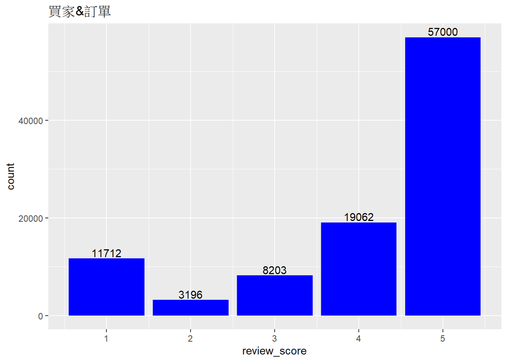

```r
OR <- OR[!duplicated(OR$review_id),]
OR %>% ggplot(aes(review_score)) +
  geom_bar(fill="blue") +
  geom_text(stat='count', aes(label=..count..), vjust=-0.2) +
  ggtitle("買家&訂單")
```

* 三星以下

```r
#下圖由左至右分別表示1~3星的評價比數各有多少。
OR <- left_join(O,R,by="order_id")
OR$review_score %>% table %>% prop.table()
```

```
.
      1       2       3       4       5
0.11858 0.03235 0.08287 0.19200 0.57420
```

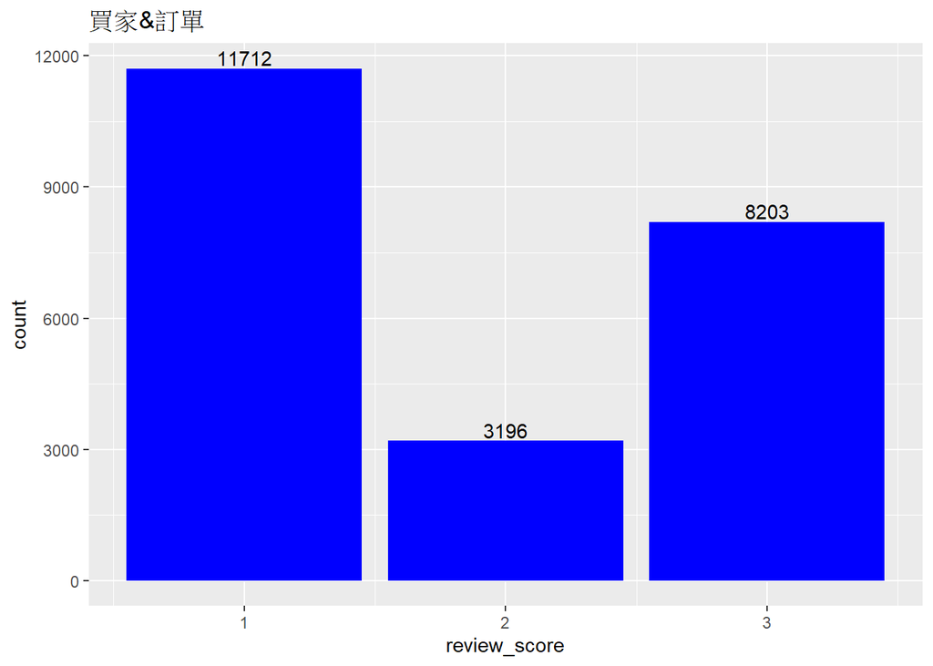

```r
OR123 <- filter(OR,review_score<=3)
OR123 <- OR123[!duplicated(OR123$review_id),]
OR123 %>% ggplot(aes(review_score)) +
  geom_bar(fill="blue") +
  geom_text(stat='count', aes(label=..count..), vjust=-0.2) +
  ggtitle("買家&訂單")
```

##### 低評分佔比

```r
OR$low_score = sapply(OR$review_score, function(x){
  ifelse(x <= 3, TRUE, FALSE)
  })
prop.table(table(OR$low_score))
```

```
 FALSE   TRUE
0.7662 0.2338
```

##### 全部評論

```r
text <- R$message %>% na.omit %>% iconv("UTF-8")
docs <- Corpus(VectorSource(text))
docs <- Corpus(VectorSource(text))
toSpace <- content_transformer(function (x , pattern ) gsub(pattern, " ", x))
docs <- docs %>%
  tm_map(toSpace, "/") %>%
  tm_map(toSpace, "@") %>%
  tm_map(toSpace, "\\|") %>%
  tm_map(removeNumbers) %>%
  tm_map(removePunctuation) %>%
  tm_map(stripWhitespace) %>%
  tm_map(content_transformer(tolower)) %>%
  tm_map(removeWords, stopwords("english"))
```

##### 文字雲1

```r
matrix <- docs %>% TermDocumentMatrix() %>% as.matrix()
words <- sort(rowSums(matrix),decreasing=TRUE)
df <- data.frame(word = names(words),freq=words)
head(df, 10)
```

```
               word  freq
product     product 18359
good           good  6146
delivery   delivery  6121
time           time  4822
delivered delivered  4561
recommend recommend  4553
arrived     arrived  4331
received   received  4326
great         great  3872
came           came  3655
```

```r
# wordcloud2 knit bug
# wordcloud2(data=df, size=1.6, color='random-dark')
```

##### 評論星等小於三

- 找到評論星等小於3之後，做成文字雲，去與所有評論的文字雲做比對。

```r
R3 <- R %>% filter(review_score <= 3)
text2 <- R3$message %>% na.omit %>% iconv("UTF-8")
docs2 <- Corpus(VectorSource(text2))
docs2 <- docs2 %>%
  tm_map(toSpace, "/") %>%
  tm_map(toSpace, "@") %>%
  tm_map(toSpace, "\\|") %>%
  tm_map(removeNumbers) %>%
  tm_map(removePunctuation) %>%
  tm_map(stripWhitespace) %>%
  tm_map(content_transformer(tolower)) %>%
  tm_map(removeWords, stopwords("english"))
```

##### 文字雲2

```r
matrix <- docs2 %>% TermDocumentMatrix() %>% as.matrix()
words <- sort(rowSums(matrix),decreasing=TRUE)
df <- data.frame(word = names(words),freq=words)
head(df, 10)
```

```
               word freq
product     product 7917
received   received 2985
bought       bought 2112
came           came 2107
delivered delivered 1957
delivery   delivery 1821
one             one 1773
time           time 1664
dont           dont 1013
purchase   purchase  946
```

```r
wordcloud2(data=df, size=1.6, color='random-dark')
```

[interactive chart not shown]

##### 評論分數等於 1

- 找到評論星等為1之後，做成文字雲，去與上面兩個文字雲做比對。

```r
R1 <- R %>% filter(review_score <= 1)
text3 <- R1$message %>% na.omit %>% iconv("UTF-8")
docs3 <- Corpus(VectorSource(text3))
docs3 <- docs3 %>%
  tm_map(toSpace, "/") %>%
  tm_map(toSpace, "@") %>%
  tm_map(toSpace, "\\|") %>%
  tm_map(removeNumbers) %>%
  tm_map(removePunctuation) %>%
  tm_map(stripWhitespace) %>%
  tm_map(content_transformer(tolower)) %>%
  tm_map(removeWords, stopwords("english"))
```

##### 文字雲3

```r
matrix <- docs3 %>% TermDocumentMatrix() %>% as.matrix()
words <- sort(rowSums(matrix),decreasing=TRUE)
df <- data.frame(word = names(words),freq=words)
head(df, 10)
```

```
               word freq
product     product 5185
received   received 2206
bought       bought 1499
delivered delivered 1357
came           came 1159
one             one 1085
delivery   delivery 1027
time           time  948
dont           dont  717
now             now  687
```

```r
wordcloud2(data=df, size=1.6, color='random-dark')
```

[output not shown]

💡 發現delivery、received、time、came在一星評論依然佔高比例，可知運送時間對顧客來說是個問題

### ◆ Part.2 物流分析

##### 分析運送和評論關係 (物流天數和評論)

```r
ds <- group_by(R, order_id) %>%
  summarise(score = mean(review_score)) %>%
  merge(O, ., by='order_id', all.x=T) %>%
  na.omit()
ds = mutate(ds, d_period=as.numeric(difftime(
  order_delivered_customer_date, order_approved_at, units="days")))
cor.test(ds$score, ds$d_period)
```

```
    Pearson's product-moment correlation

data:  ds$score and ds$d_period
t = -110, df = 96459, p-value <0.0000000000000002
alternative hypothesis: true correlation is not equal to 0
95 percent confidence interval:
 -0.34065 -0.32944
sample estimates:
     cor
-0.33506
```

💡 運送天數與評論星等的相關性，發現為`-0.33506`可得知運送天數越長則星等給的越低有明顯負相關

##### 畫出關係盒狀圖

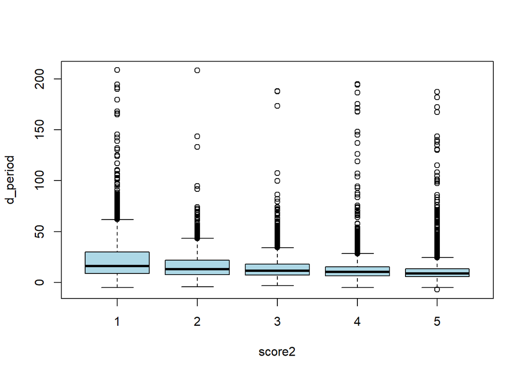

```r
score2 <- round(ds$score, digits = 0)
ds <- cbind(ds, score2)
ds = ds[,-12]

boxplot(formula=d_period~score2,
        data = ds, xlab="score2", ylab = "d_period", col ="lightblue")
```

##### 去除離群值

```r
rosnerTest(ds$d_period)
```

```
Results of Outlier Test
-------------------------

Test Method:                     Rosner's Test for Outliers

Hypothesized Distribution:       Normal

Data:                            ds$d_period

Sample Size:                     96461

Test Statistics:                 R.1 = 20.636
                                 R.2 = 20.665
                                 R.3 = 19.287

Test Statistic Parameter:        k = 3

Alternative Hypothesis:          Up to 3 observations are not
                                 from the same Distribution.

Type I Error:                    5%

Number of Outliers Detected:     3

  i Mean.i   SD.i  Value Obs.Num  R.i+1 lambda.i+1 Outlier
1 0 12.130 9.5160 208.50   76141 20.636     5.0191    TRUE
2 1 12.128 9.4950 208.34   10282 20.665     5.0191    TRUE
3 2 12.126 9.4741 194.85   17882 19.287     5.0191    TRUE
```

```r
outlier <- 15 + 1.5*IQR(ds$d_period);outlier
```

```
[1] 28.247
```

```r
ds_outlier = ds %>% filter(ds$d_period > 26.901)#ds篩出outlier
ds = anti_join(ds, ds_outlier, by = "order_id")
which.max(ds$d_period)
```

```
[1] 19513
```

##### 畫出去除離群值的盒狀圖

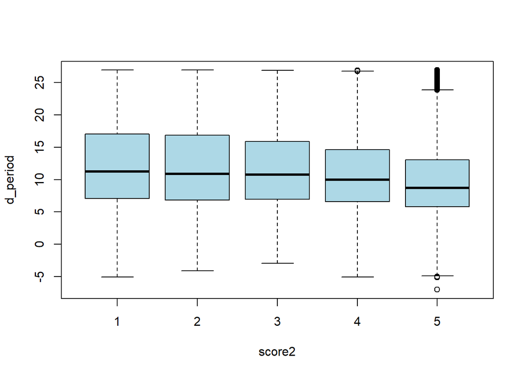

```r
score2 <- round(ds$score, digits = 0)
ds <-cbind(ds, score2)
ds = ds[,-12]

boxplot(formula=d_period~score2,
        data = ds, xlab="score2", ylab = "d_period", col ="lightblue")
```

💡 發現運送天數越長則星等給的越低有明顯負相關，只要改善這點顧客的滿意度才有可能提升

##### 運費分析

```r
IS <- left_join(I,S)
OC <- left_join(O,C)
BAA <- OC %>% left_join(.,IS,by="order_id") %>% left_join(.,P)
tapply(FP_ratio <- BAA$freight_value/BAA$price,BAA$customer_state,mean,na.rm=TRUE)
```

```
     AC      AL      AM      AP      BA      CE      DF      ES      GO      MA
0.51165 0.47448 0.49814 0.38450 0.39495 0.43154 0.34308 0.35225 0.35161 0.54932
     MG      MS      MT      PA      PB      PE      PI      PR      RJ      RN
0.33043 0.34000 0.39318 0.47359 0.51160 0.45000 0.49984 0.34496 0.32727 0.50633
     RO      RR      RS      SC      SE      SP      TO
0.59419 0.58905 0.35579 0.34603 0.46495 0.26541 0.49946
```

##### 抓前七高的州

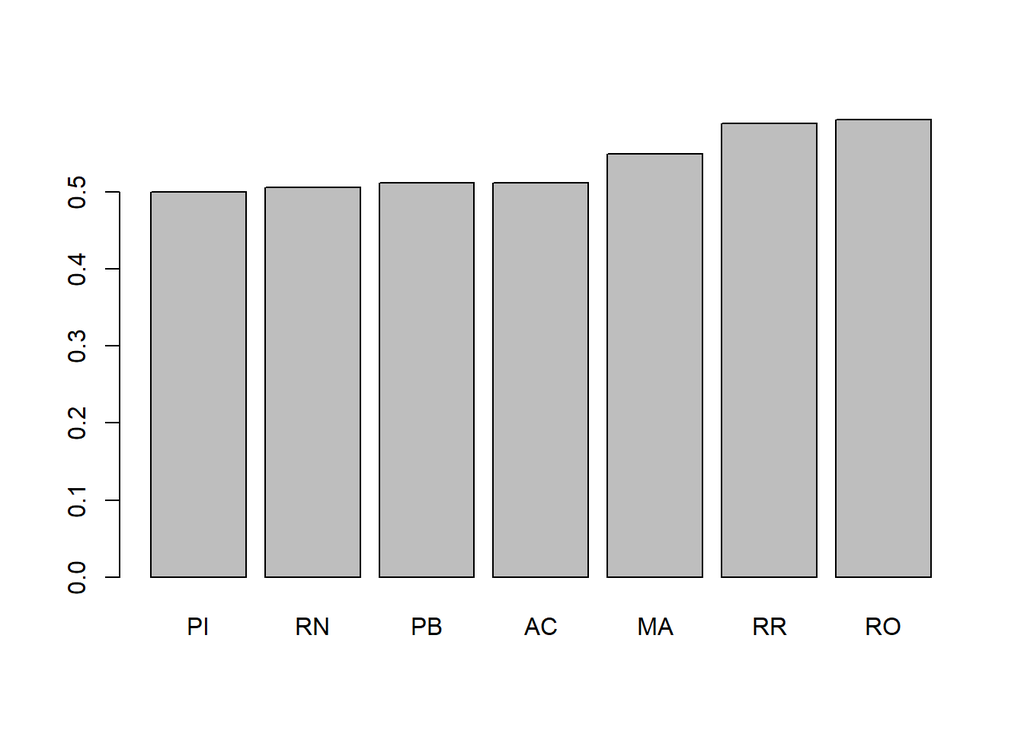

```r
tapply(FP_ratio <- BAA$freight_value/BAA$price,BAA$customer_state,mean,na.rm=TRUE)%>% sort %>% tail(7) %>% barplot
```

💡 運費除以價格比例偏高，代表消費者可能會因運費而沒有在電商平台上購買的意願

### ◆ Part.3 地圖探索

##### > 理由：

1. 統計出各產品的運費總額、各地區的訂單需求。藉由以上分析，得出運費產生主要在哪些產品別的運輸上。
2. 客戶與工廠的分佈概況，客戶與工廠之間距離接近的狀況，可採取直接領貨的方式。並計算實際送達的日數落差，來進行運輸效率之分析。
3. 經由以上產品運費與運輸效率的統計與分析，未來可做為電商設置集運中心的可能性評估。

##### 地圖

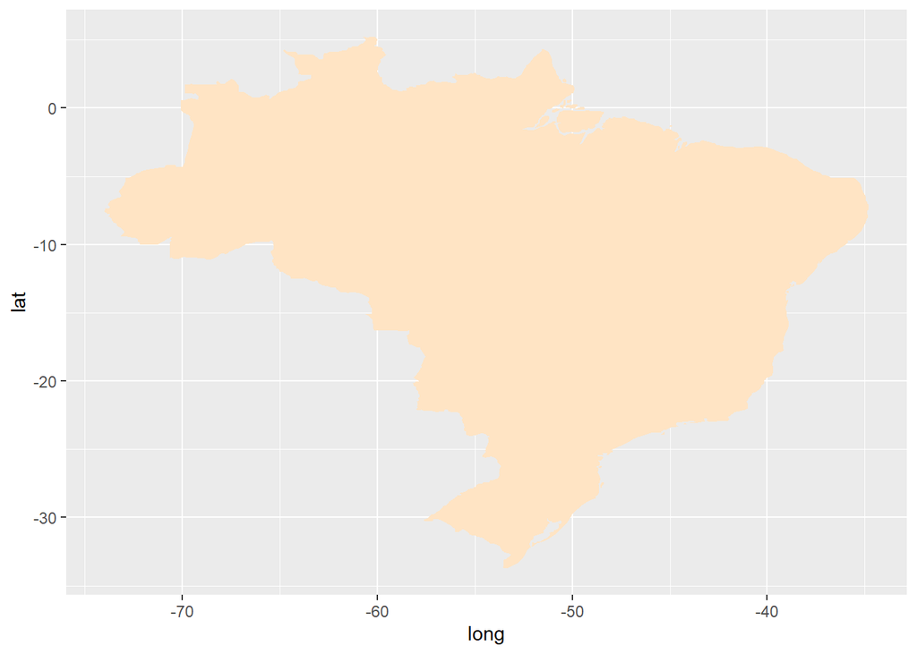

```r
# Removing some outliers
# Brazils most Northern spot is at 5 deg 16′ 27.8″ N latitude.;
G = G[G$geolocation_lat <= 5.27438888,]
# it’s most Western spot is at 73 deg, 58′ 58.19″W Long.
G = G[G$geolocation_lng >= -73.98283055,]
# It’s most southern spot is at 33 deg, 45′ 04.21″ S Latitude.
G = G[G$geolocation_lat >= -33.75116944,]
# It’s most Eastern spot is 34 deg, 47′ 35.33″ W Long.
G = G[G$geolocation_lng <=  -34.79314722,]
Brazil = map_data("world") %>% filter(region=="Brazil")
BM <- borders("world", regions = "Brazil", fill = "grey70", colour = "black")
# 巴西地圖基底
bm = ggplot() + geom_polygon(data = Brazil, aes(x=long, y = lat, group = group), fill="Bisque");bm
```

##### 買賣家位置設定

```r
sl <- G %>% group_by(geolocation_city) %>% summarise(s_lat = max(geolocation_lat),s_lng=max(geolocation_lng))
cl <- G %>% group_by(geolocation_city) %>% summarise(c_lat = max(geolocation_lat),c_lng=max(geolocation_lng))

# clean
sl = sl[sl$s_lat <= 5.27438888,];sl = sl[sl$s_lng >= -73.98283055,]
sl = sl[sl$s_lat >= -33.75116944,];sl = sl[sl$s_lng <=  -34.79314722,]

cl = cl[cl$c_lat <= 5.27438888,];cl = cl[cl$c_lng >= -73.98283055,]
cl = cl[cl$c_lat >= -33.75116944,];cl = cl[cl$c_lng <=  -34.79314722,]

sc_loc <- c(sl$s_lat, sl$s_lng, cl$c_lat, cl$c_lng)
```

```r
# bm + geom_point(data = G, aes(x=geolocation_lng, y=geolocation_lat, color=geolocation_state),size=0.2)
```

##### 合併成大表

```r
BAA <- BAA  %>%
  left_join(.,sl,by=c('seller_city'='geolocation_city')) %>%
  left_join(.,cl,by=c('customer_city'='geolocation_city'))
```

- 繪出個訂單狀態圖
- 參考:https://www.kaggle.com/anshumoudgil/olist-a-brazilian-e-commerce/code

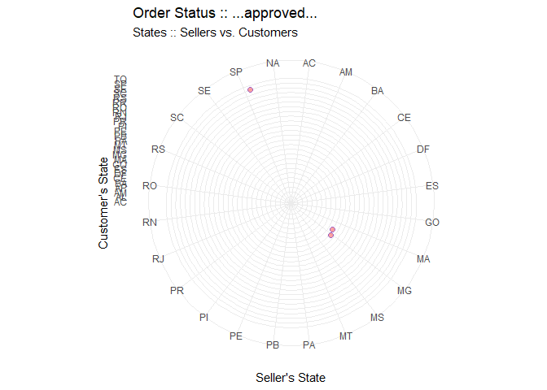

```r
OS_plot <- ggplot(BAA, aes(y = customer_state, x = seller_state))+
  geom_jitter(fill = alpha("red", 0.001), color = "blue", alpha = 0.36, size = 2.1, shape = 21) +
  coord_polar(start = 0) +
  theme_minimal() +
  labs(title ="Order Status :: ...{closest_state}...",
  x = "Seller's State", y = "Customer's State",
  subtitle = "States :: Sellers vs. Customers") +
  transition_states(order_status, transition_length = 5, state_length = 5)
animate(OS_plot)
```

💡 發現所有訂單幾乎聚集在某幾個州

##### 顧客分布

```r
n_distinct(BAA$customer_unique_id)
```

```
[1] 96096
```

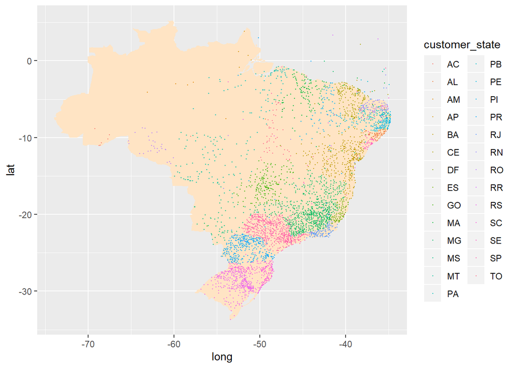

```r
bm + geom_point(data=BAA,aes(x=c_lng,y=c_lat,color=customer_state),size=0.2)
```

##### 賣家分布

```r
n_distinct(BAA$seller_id)
```

```
[1] 3096
```

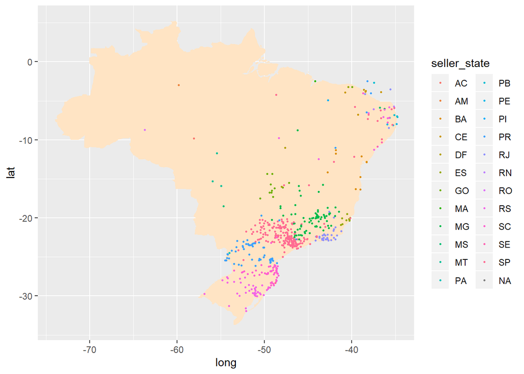

```r
bm + geom_point(data=BAA,aes(x=s_lng,y=s_lat,color=seller_state),size=0.5)
```

💡 顧客及賣家都聚集在巴西東南部

##### 買賣家距離

- 按生意排名前300

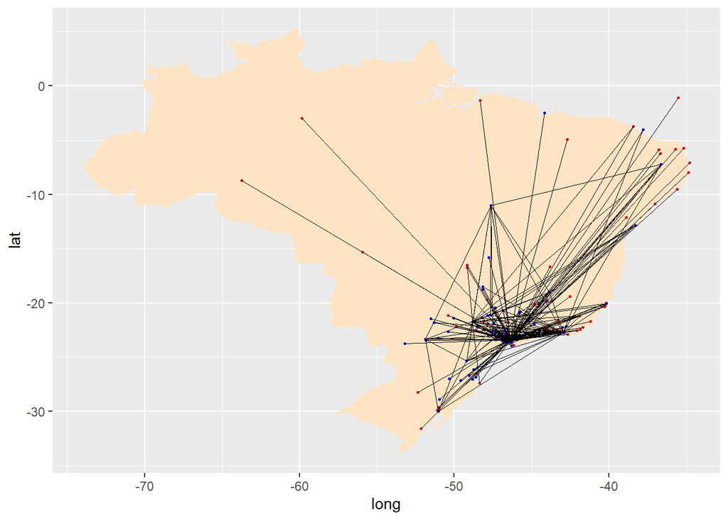

```r
scc <- BAA %>%
  group_by(s_lat,s_lng,c_lat,c_lng) %>%
  summarise(count=n()) %>%
  arrange(desc(count))
scc1 <- scc[1:300,]
bm +
  geom_point(data=scc1, aes(x=c_lng, y=c_lat), col="red", size=0.5) +
  geom_point(data=scc1, aes(x=s_lng, y=s_lat), col="blue", size=0.5) +
  geom_segment(data=scc1, aes(x=s_lng, y=s_lat, xend=c_lng, yend=c_lat),
              col="black", size=.01)
```

##### 2. 分析所有訂單依照「產品、分類」的運費總額與產品價格關係

```r
# 分析產品分類的運費總額、(產品價格-運費)的平均
freightFee1 = merge(x = I, y = P, by = "product_id", all.x =  TRUE) %>%
   select (product_id, product_category_name, price, freight_value) %>%
  group_by (product_category_name) %>%
  summarise(
    totalFreight = sum(freight_value),
    pfMeanDiff = mean(price-freight_value)
  )
summary(freightFee1)
```

```
 product_category_name  totalFreight      pfMeanDiff
 Length:74             Min.   :    41   Min.   :  11.7
 Class :character      1st Qu.:  1702   1st Qu.:  65.8
 Mode  :character      Median :  6629   Median :  94.6
                       Mean   : 30431   Mean   : 124.8
                       3rd Qu.: 31199   3rd Qu.: 122.8
                       Max.   :204693   Max.   :1049.9
```

##### 3. 各地區(city, state)有多少筆訂單

- 我們就要依`customer_id`做彙總； 先從訂單(`O`)做起

```r
#1.客戶所在地區的訂單數量 Left join, 可能有的地區沒有訂單
OrdersOfState = left_join(C, O) %>%
  count(customer_state, sort=TRUE)
summary(OrdersOfState)
```

```
 customer_state           n
 Length:27          Min.   :   46
 Class :character   1st Qu.:  382
 Mode  :character   Median :  907
                    Mean   : 3683
                    3rd Qu.: 2760
                    Max.   :41746
```

```r
#2.客戶所在城市的訂單數量 Left join, 可能有的城市沒有訂單
OrdersOfCity = left_join(C, O) %>%
  count(customer_city, sort=TRUE)
summary(OrdersOfCity)
```

```
 customer_city            n
 Length:4119        Min.   :    1.0
 Class :character   1st Qu.:    1.0
 Mode  :character   Median :    3.0
                    Mean   :   24.1
                    3rd Qu.:    9.0
                    Max.   :15540.0
```

##### 3. 比對客戶與賣家在各地區的運費、產品價格，找出關聯性

1. 從訂單資料O, I 兩個資料表開始做為資料探索的起點，透過與顧客C、賣家S的 join， group後，summarise 算出各州State 的運費與產品價格
2. 在join 過程中發現有顧客並沒有相關訂單資料，因此改採left join 並排除NA值
3. 透過比對各州state 顧客與賣家的運費與產品價格，發現SP是銷售與運送最大量的州，而且與其他州差距巨大，因此在SP建置實體通路商場，將可以進一步提高銷售、降低運費

```r
#先將訂單與細項join
OrderItem1 <- inner_join(O, I, by = "order_id")
#1. 計算顧客的訂單中的運費加總、產品加總價格
CustomerOrder1<-OrderItem1 %>%
  group_by(customer_id) %>%
  summarise(
    customerTotalFreight = sum(freight_value),
    customerTotalPrice = sum(price)
  )

#2.找出顧客地區的運費總額 、平均運費、產品平均價格, Left join 可能有的顧客沒有訂單
CustomerStateFee <- left_join(C, CustomerOrder1, by = "customer_id") %>%
  group_by(customer_state) %>%
  summarise(
    customerStateFreight = sum(customerTotalFreight, na.rm=TRUE),
    customerStatePrice = sum(customerTotalPrice, na.rm=TRUE)
  ) %>%
  arrange(customer_state)

#3. 計算賣家的訂單中的運費加總、產品加總價格
SellerOrder1<-OrderItem1 %>%
  group_by(seller_id) %>%
  summarise(
    sellerTotalFreight = sum(freight_value),
    sellerTotalPrice = sum(price)
  )

#4.找出賣家地區的運費總額 、平均運費、產品平均價格, Left join 可能有的賣家沒有訂單
SellerState <- left_join(S, SellerOrder1, by = "seller_id")
SellerStateFee <- SellerState %>%
  group_by(seller_state) %>%
  summarise(
    sellerStateFreight = sum(sellerTotalFreight, na.rm=TRUE),
    sellerStatePrice = sum(sellerTotalPrice, na.rm=TRUE)
  ) %>%
  arrange(seller_state)

# outter join 兩張表
StateAllFee <- full_join(CustomerStateFee, SellerStateFee, by = c("customer_state" = "seller_state")) %>% arrange(desc(sellerStateFreight))

StateAllFee
```

```
# A tibble: 27 x 5
   customer_state customerStateFr~ customerStatePr~ sellerStateFrei~
   <chr>                     <dbl>            <dbl>            <dbl>
 1 SP                      718723.         5202955.         1482488.
 2 MG                      270853.         1585308.          212595.
 3 PR                      117852.          683084.          197014.
 4 SC                       89660.          520553.          106547.
 5 RJ                      305589.         1824093.           93830.
 6 RS                      135523.          750304.           57243.
 7 BA                      100157.          511350.           19701.
 8 DF                       50626.          302604.           18494.
 9 GO                       53115.          294592.           12566.
10 PE                       59450.          262788.           12392.
# ... with 17 more rows, and 1 more variable: sellerStatePrice <dbl>
```

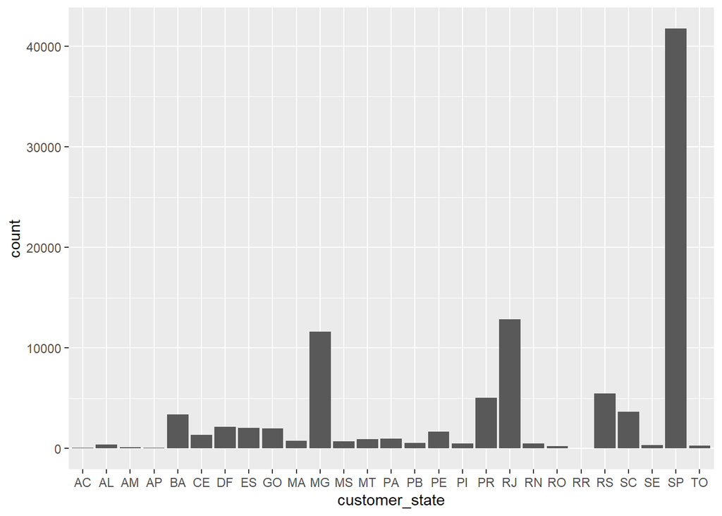

```r
OC1 <- left_join(O, C, by = "customer_id")
OC1 <- OC1 %>%
  group_by(customer_state) %>%
  mutate(no_order=n()) %>%
  arrange(desc(no_order))
ggplot(OC1,aes(customer_state)) + geom_bar()
```

💡 訂單數量前三名的州為SP、RJ、MG(>10000)，其他有較多訂單數量的州分別為RS、PR、SC、BA(>3000)